## 1. **Grafické zobrazení řady, komentář dat**

Analyzovaná data obsahují návštevnost a tržby městského bazénu. Řada obsahuje denní data za roky 2023 a 2024. Data budeme zkoumat v časovém rámci roku. Naší hlavní řadou bude návštěvnost, vedlejší řadou bude tržba.

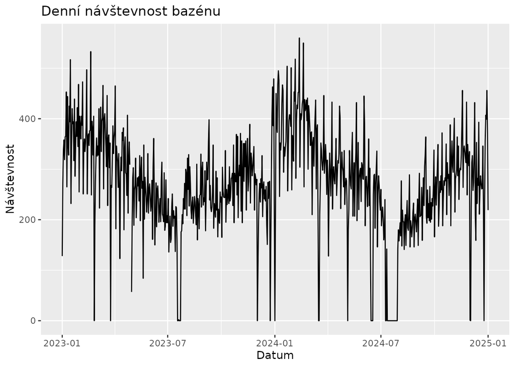

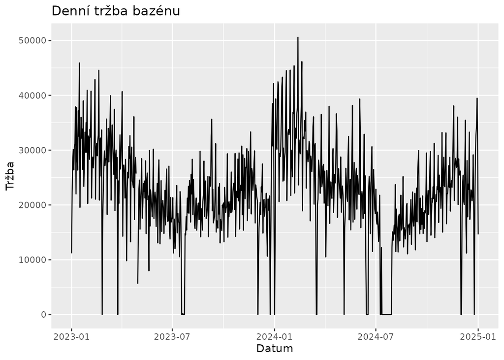

I když tento fakt není moc viditelný, řada obsahuje nulové a prázdné hodnoty. Tyto hodnoty jsou způsobeny dny, kdy bazén byl uzavřen/vyhrazen pro nějaké akce a odstávky systému, v tomto pořadí. Pro naše účely v některých případech budou chybějící hodnoty nahrazeny nulami. Data ukazují jasnou sezónnost, konstantně vypadající trend.

## 2. Dekompozice a idenfikace trendu pomocí vyhlazení řady

### Klouzavé průměry

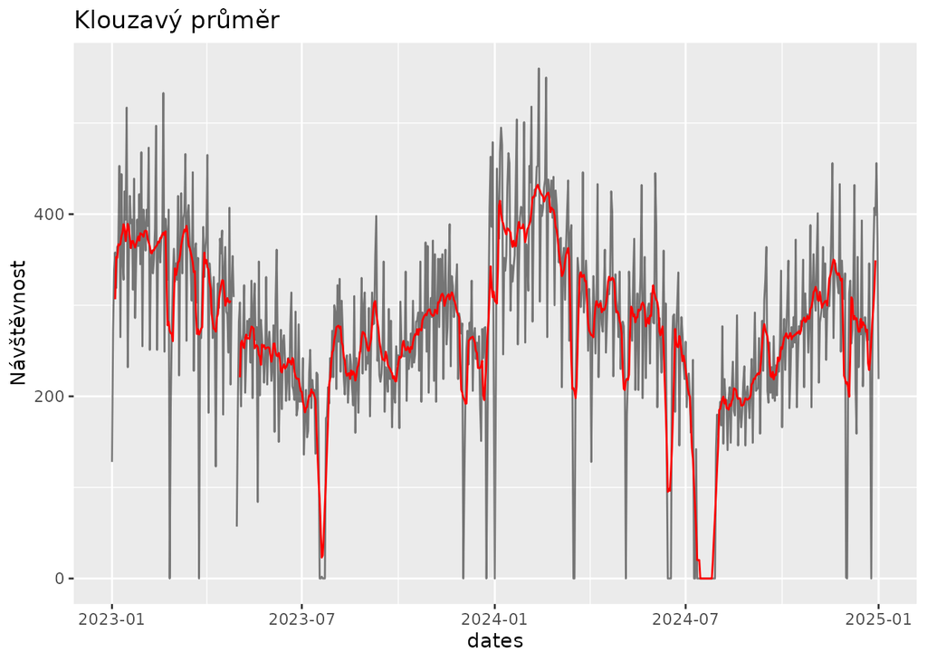

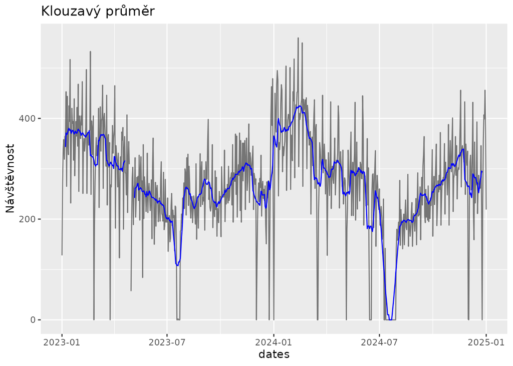

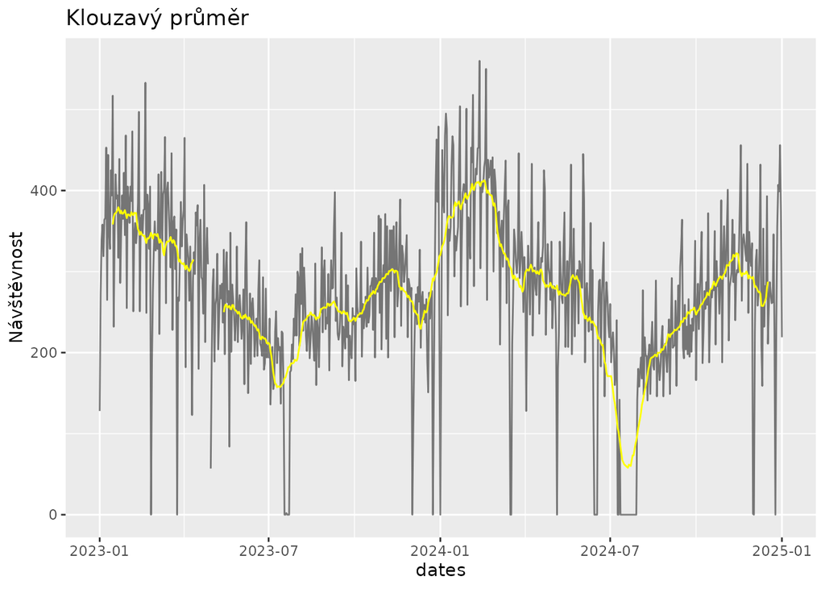

Sedmidenní klouzavý průměr neposkytuje dostatečné vyhlazení, zatímco třicetidenní poskytuje moc agresivní vyhlazení. Čtrnáctidenní vyhlazení vypadá jako optimum. Nulové hodnoty trochu skreslují výsledek. V datech lze vidět sezónnost na úrovni roku.

### Exponenciální vyrovnání

```
##              Length Class  Mode
## fitted       1468   mts    numeric
## x             732   ts     numeric
## alpha           1   -none- numeric
## beta            1   -none- numeric
## gamma           1   -none- numeric
## coefficients  367   -none- numeric
## seasonal        1   -none- character
## SSE             1   -none- numeric
## call            2   -none- call
```

```
##     alpha
## 0.3635206
```

```
## beta
##    0
```

```
## gamma
##     1
```

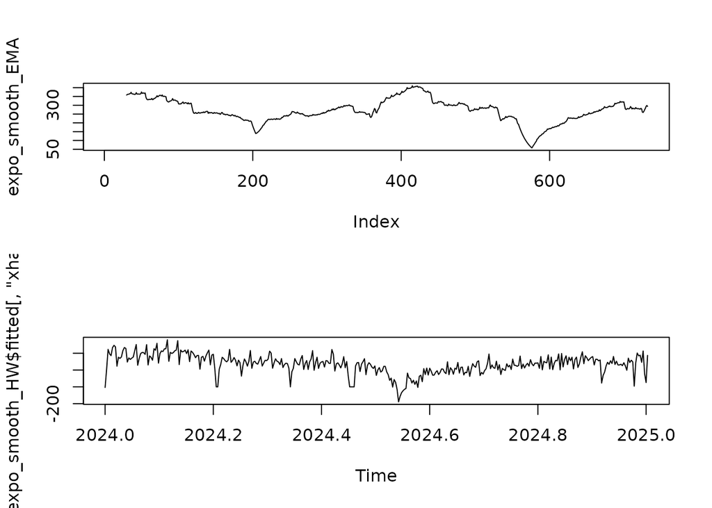

Toto nám říká, že podle Holt-Wintersovy metody je trend konstatní, a řada obsahuje sezónnost. Nulová beta značí konstantní trend, a gamma na hodnotě 1 značí silnou sezónnost.

## 3. Optimální modely pro řadu

### Funkční zápis

```
## [1] 0.2036347
```

```
## [1] 0.02609348
```

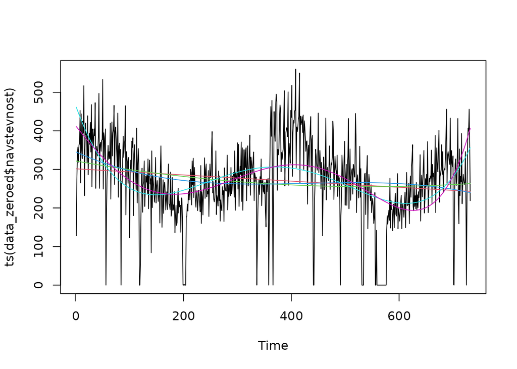

```
## [1] 8884.462
```

```
## [1] 8885.455
```

```
## [1] 8886.53
```

```
## [1] 8776.674
```

```
## [1] 8763.524
```

Nejlépe vypadající trend je u polynomu stupně 5, nicméně kritérium r^2 napovídá, že tato křivka nevysvětluje velkou část residuí. Je možné že vyšší polynomiální stupeň bude křivku vystihovat ještě lépe, nicméně nárust v přesnosti bude logaritmický. Stupeň 5 postačí. Pozoruhodné ještě je, že kritéria BIC lineární model je lepší než kvadratický a kubický.

### Loess model

```
##  Call:
##  stl(x = ts_navs_zero, s.window = "periodic")
##
##  Time.series components:
##     seasonal              trend            remainder
##  Min.   :-274.15713   Min.   :264.5036   Min.   :-195.38418
##  1st Qu.: -61.42071   1st Qu.:269.5713   1st Qu.: -19.99489
##  Median :   2.81245   Median :271.6094   Median :   0.25912
##  Mean   :  -0.19489   Mean   :272.2501   Mean   :   0.25352
##  3rd Qu.:  61.90248   3rd Qu.:274.9405   3rd Qu.:  20.81481
##  Max.   : 270.70239   Max.   :278.5305   Max.   : 204.82990
##  IQR:
##      STL.seasonal STL.trend STL.remainder data
##      123.323        5.369    40.810       119.250
##    % 103.4          4.5      34.2         100.0
##
##  Weights: all == 1
##
##  Other components: List of 5
##  $ win  : Named num [1:3] 7321 549 365
##  $ deg  : Named int [1:3] 0 1 1
##  $ jump : Named num [1:3] 733 55 37
##  $ inner: int 2
##  $ outer: int 0
```

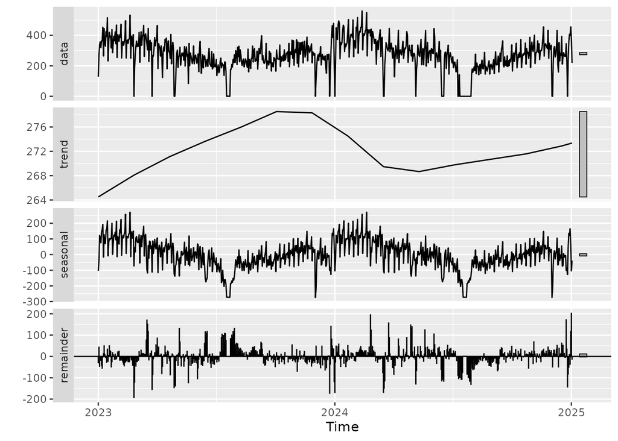

Loess potvrzuje sezónnost, ale narozdíl od Holt-Wintersovy metody promítá kladný, nekonstantní trend.

## 4. Sarima model

```
## Series: ts_navs_full
## ARIMA(1,0,0)(0,1,0)[365]
##
## Coefficients:
##          ar1
##       0.5488
## s.e.  0.0440
##
## sigma^2 = 6155:  log likelihood = -2110.06
## AIC=4224.12   AICc=4224.15   BIC=4231.93
##
## Training set error measures:
##                      ME     RMSE      MAE MPE MAPE      MASE         ACF1
## Training set -0.7753245 55.39767 26.39543 NaN  Inf 0.4191938 -0.007286574
```

```
## Series: ts_navs_full
## ARIMA(1,0,0)(0,1,0)[365]
##
## Coefficients:
##          ar1
##       0.5488
## s.e.  0.0440
##
## sigma^2 = 6155:  log likelihood = -2110.06
## AIC=4224.12   AICc=4224.15   BIC=4231.93
##
## Training set error measures:
##                      ME     RMSE      MAE MPE MAPE      MASE         ACF1
## Training set -0.7753245 55.39767 26.39543 NaN  Inf 0.4191938 -0.007286574
```

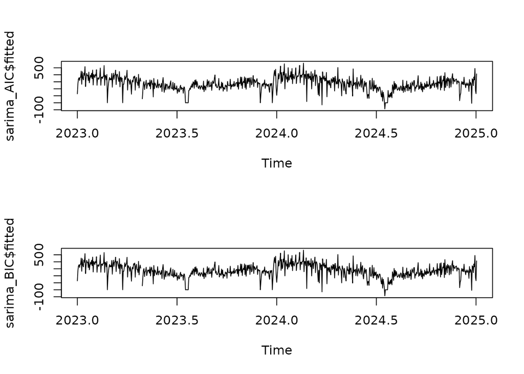

Volba podle AIC i BIC nám automaticky zvolí SARIMA model (1,0,0)(0,1,0)[365]. Toto znamená následující: - Hodnota autoregrese je 1, což znamená že se využívá pouze hodnota předchozího kroku. - Řada není diferencována, tudíž již je stacionární. - Řadu je nutno sezónně diferencovat, tudíž máme další důkaz sezónnosti.

## 5. ** Závislosti na jiných řadách, dynamické modely **

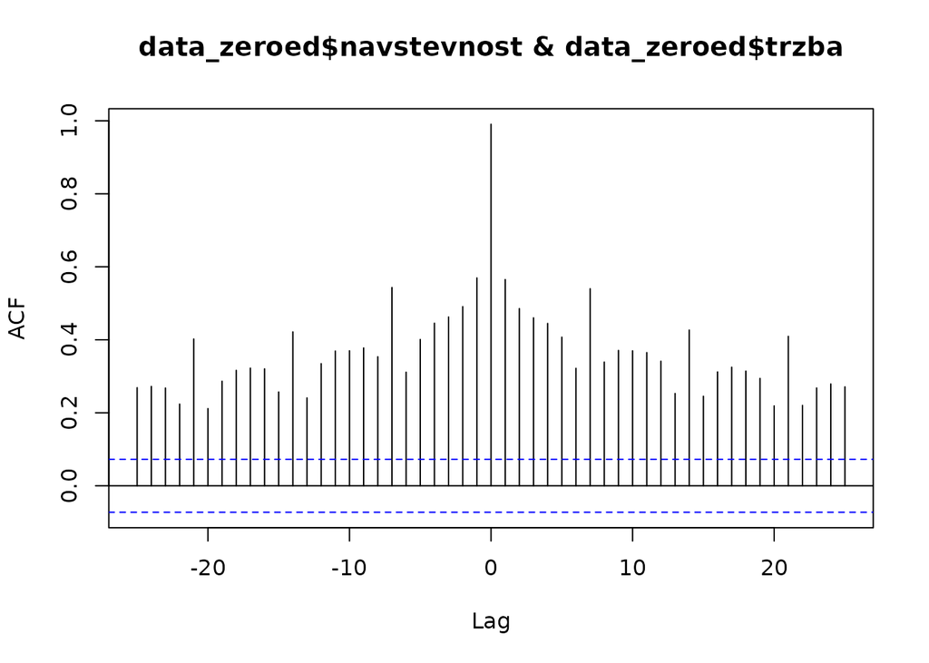

Vzhledem k tomu že kroskorelační funkce nabývá hodnoty 1 v lagu 0, znamená že mezi návštěvností a tržbou bude nějaká korelace. Selský rozum by nám asi napověděl, že by tam mohla být pozitivní lineární závislost.

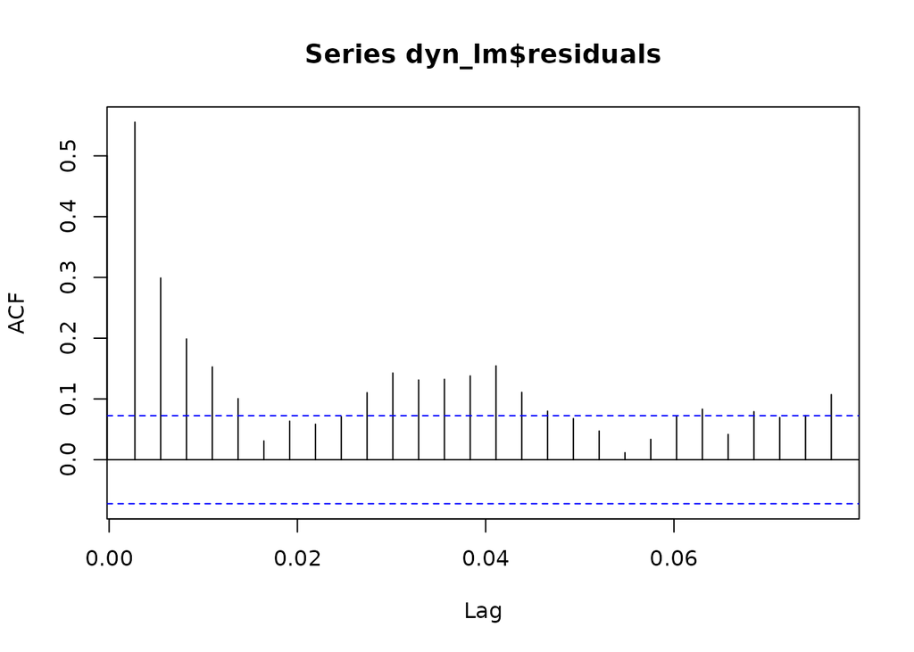

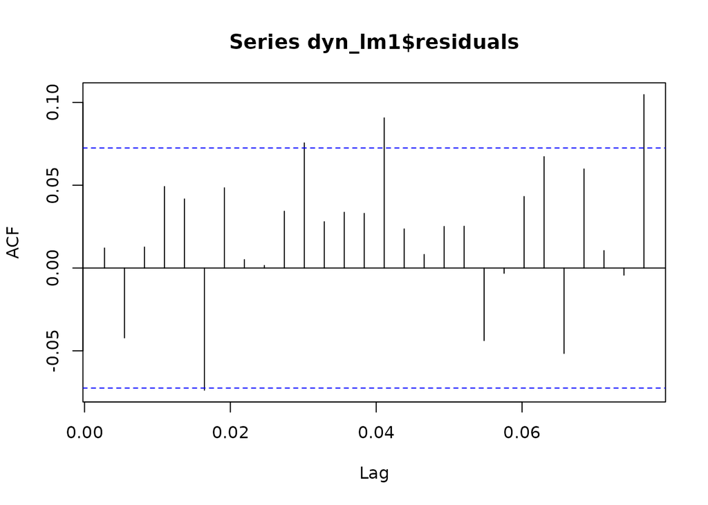

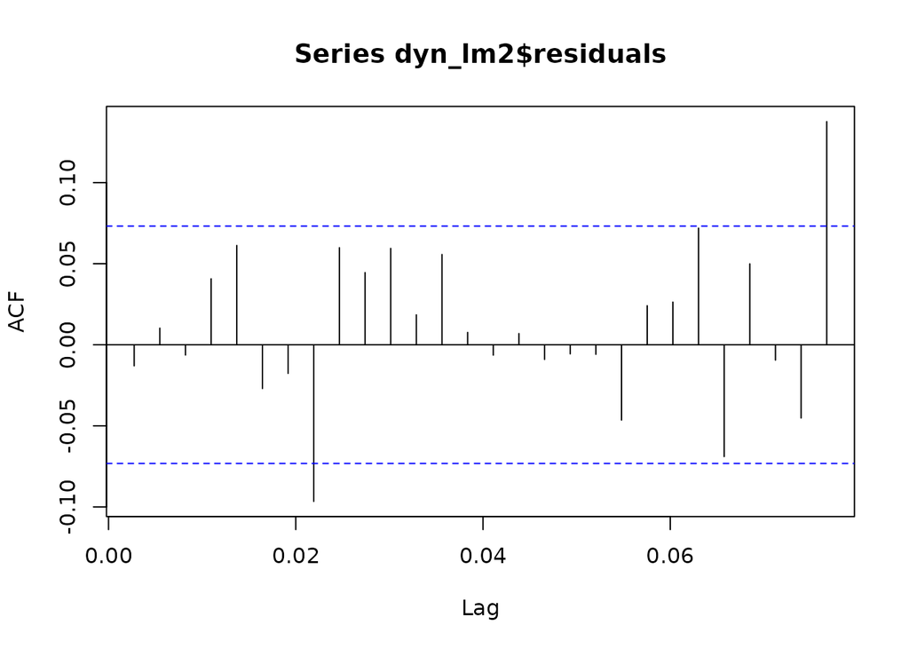

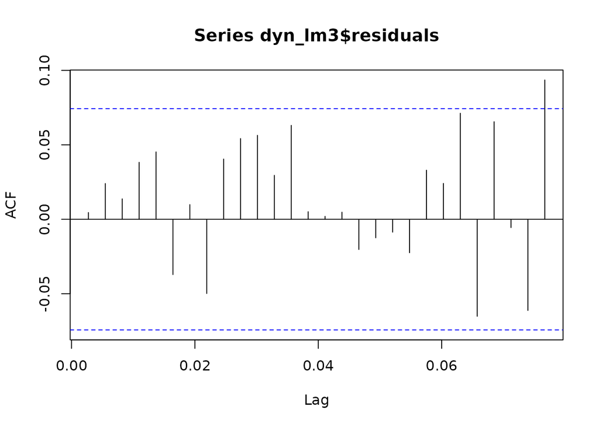

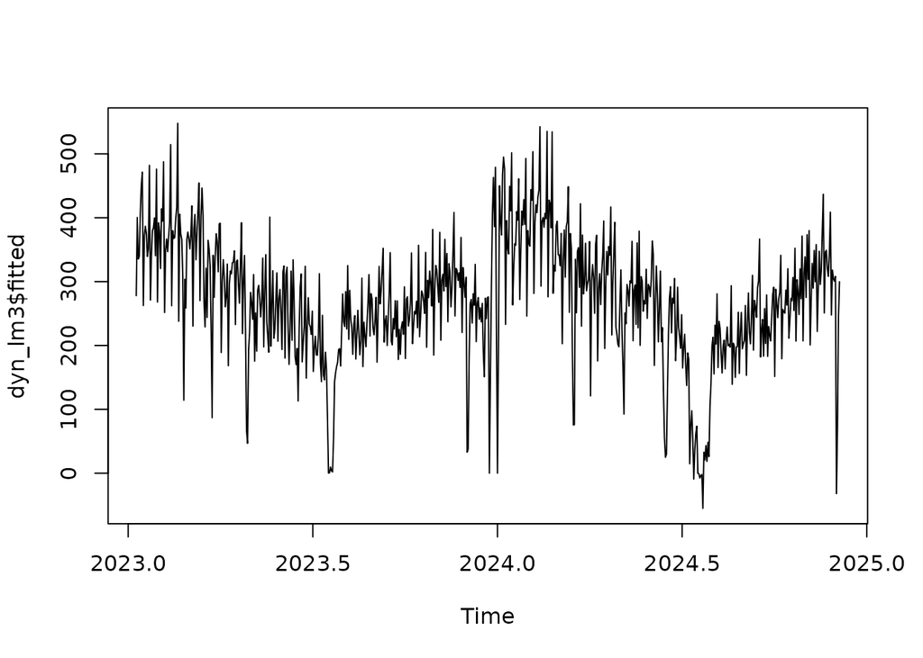

## 6. **Analýza residuí**

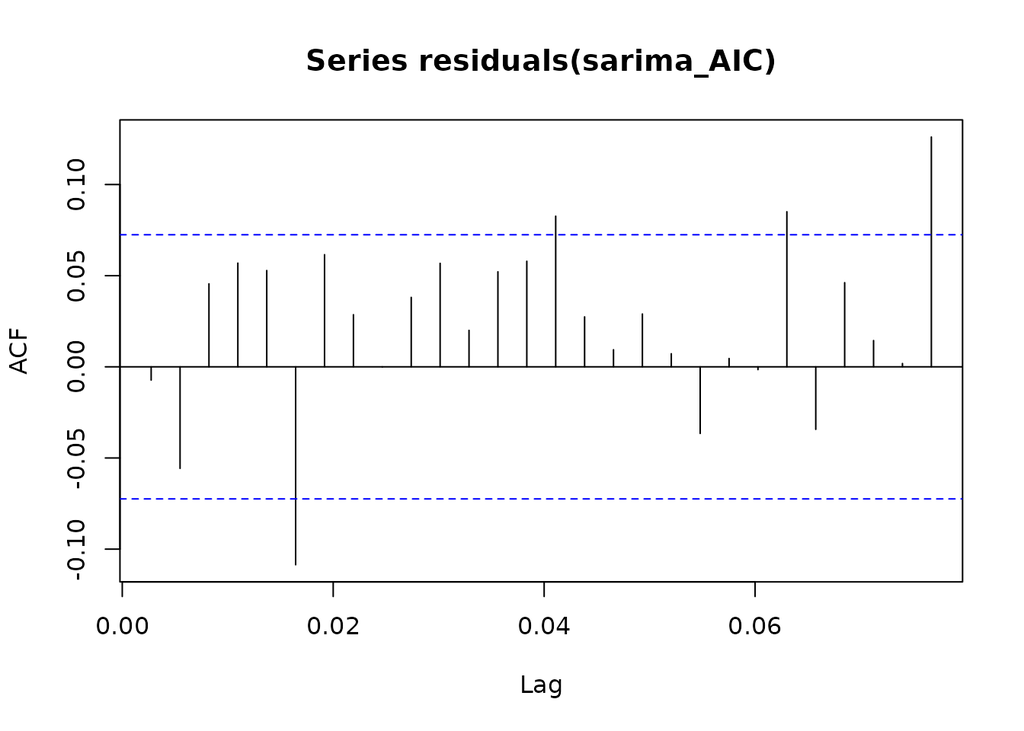

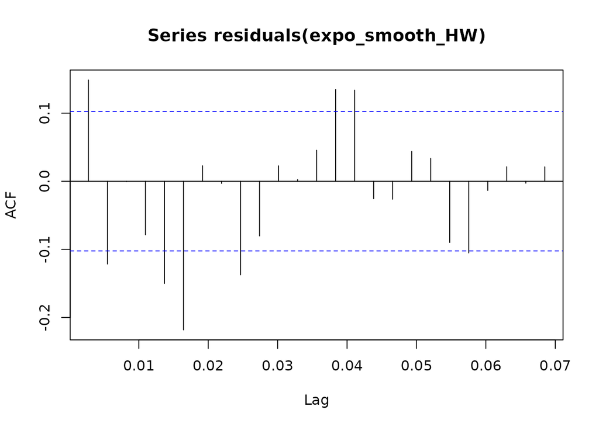

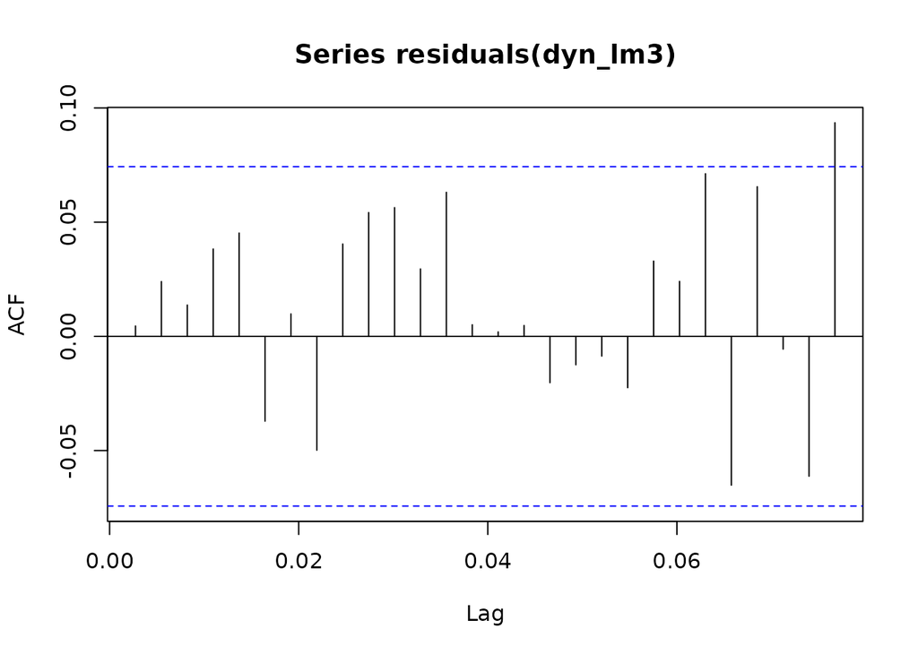

Residua u modelů `sarima_AIC` a `expo_smooth_HW` vykazují autokorelaci, což znamená, že modely plně nezachytily strukturu dat. U modelu `dyn_lm3` je autokorelace menší, ale stále přítomná. V následující sekci se pokusíme tento problém vyřešit pomocí jiných modelů.

## 7. **Predikce**

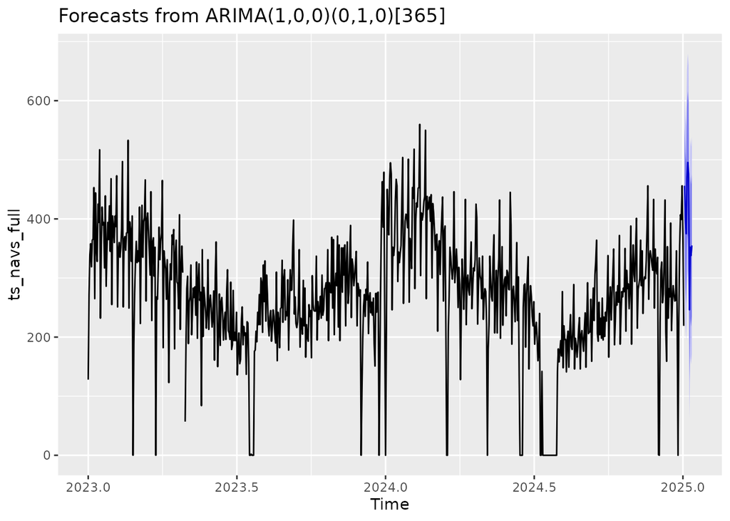

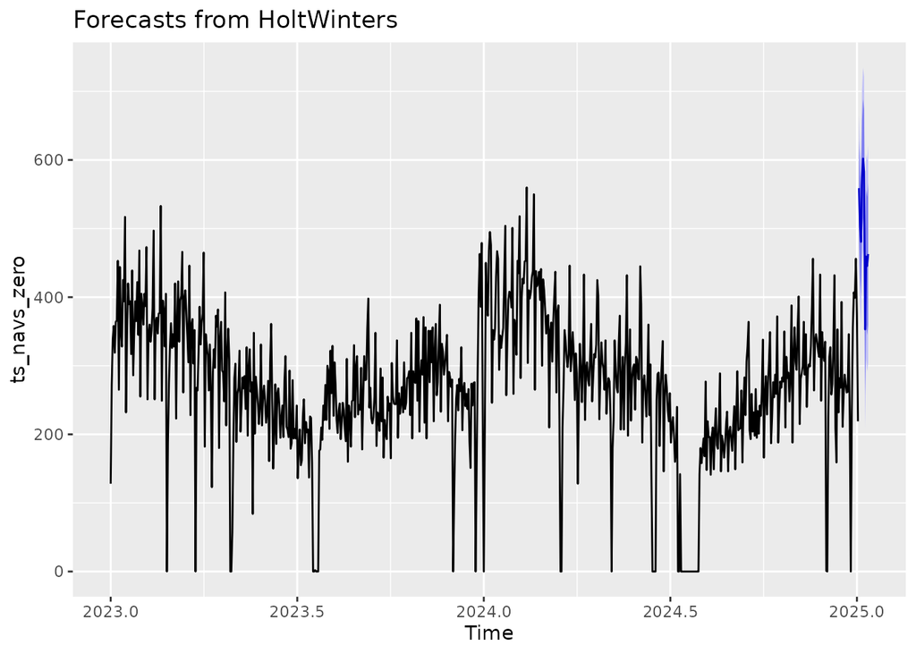

Sarima předpovídá celkem smysluplně. Holt-Winters model vypadá relativně problémově.

## 8. ** Porovnání modelů a závěr **

Sarima je jediný model který se reálně povedl, zbytek modelů má silné chyby. Vypadá to že se návštevnost bude mírně zvedat během zimy.

## 9. **Řešení autokorelace residuí**

Jak bylo zmíněno v sekci 6, některé modely vykazují autokorelaci v residuích. To znamená, že v datech je stále nějaká struktura, kterou model nezachytil.

### Lineární regrese

Zkusíme nejprve jednoduchou lineární regresi návštěvnosti na tržbě, jak bylo doporučeno.

```
##
## Call:
## lm(formula = navstevnost ~ trzba, data = data_zeroed)
##
## Residuals:
##     Min      1Q  Median      3Q     Max
## -60.527  -9.682   0.032   9.789  65.566
##
## Coefficients:
##              Estimate Std. Error t value Pr(>|t|)
## (Intercept) 1.127e+01  1.439e+00   7.828 1.74e-14 ***
## trzba       1.167e-02  5.979e-05 195.122  < 2e-16 ***
## ---
## Signif. codes:  0 '***' 0.001 '**' 0.01 '*' 0.05 '.' 0.1 ' ' 1
##
## Residual standard error: 14.36 on 730 degrees of freedom
## Multiple R-squared:  0.9812, Adjusted R-squared:  0.9812
## F-statistic: 3.807e+04 on 1 and 730 DF,  p-value: < 2.2e-16
```

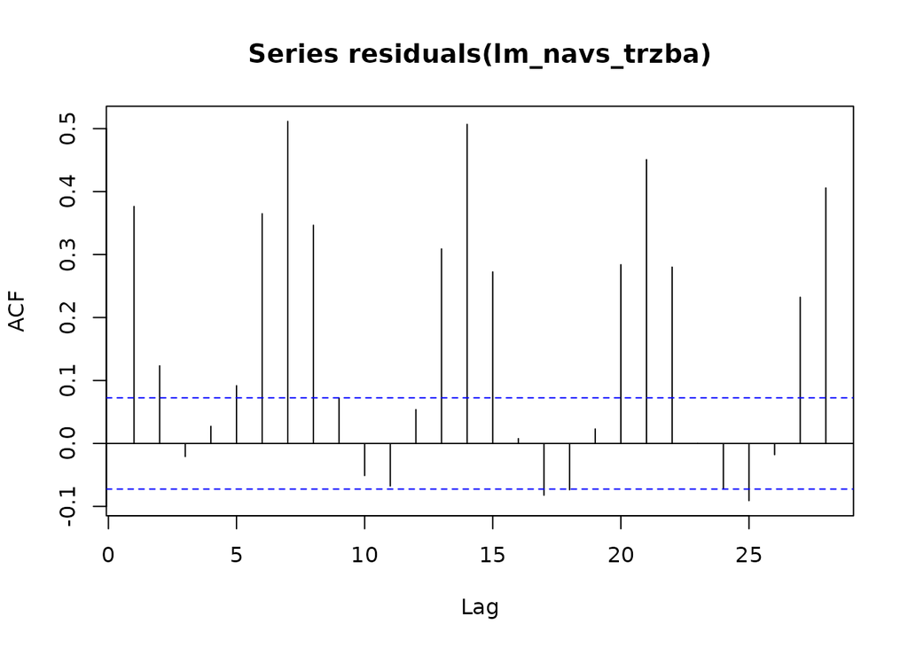

Jak je vidět z ACF grafu, residua jsou stále silně autokorelovaná. Lineární model sám o sobě nestačí, protože ignoruje časovou strukturu dat (trend, sezónnost).

### Lineární regrese s týdenní sezónností

ACF graf pro lineární regresi ukazuje silnou autokorelaci každých 7 lagů, což naznačuje přítomnost týdenní sezónnosti. Tento problém se pokusíme vyřešit přidáním dne v týdnu jako prediktoru do modelu. Pro tento účel si vytvoříme novou dočasnou datovou sadu.

```
##
## Call:
## lm(formula = navstevnost ~ trzba + den_v_tydnu, data = data_weekly)
##
## Residuals:
##     Min      1Q  Median      3Q     Max
## -57.025  -8.187   0.233   7.510  58.936
##
## Coefficients:
##                 Estimate Std. Error t value Pr(>|t|)
## (Intercept)    9.243e+00  1.287e+00   7.180 1.73e-12 ***
## trzba          1.176e-02  5.360e-05 219.337  < 2e-16 ***
## den_v_tydnu.L -7.453e+00  1.241e+00  -6.004 3.04e-09 ***
## den_v_tydnu.Q -1.641e+01  1.240e+00 -13.228  < 2e-16 ***
## den_v_tydnu.C  3.166e-01  1.238e+00   0.256   0.7983
## den_v_tydnu^4 -1.332e+00  1.247e+00  -1.068   0.2858
## den_v_tydnu^5  2.506e+00  1.240e+00   2.022   0.0436 *
## den_v_tydnu^6  1.011e+00  1.240e+00   0.816   0.4149
## ---
## Signif. codes:  0 '***' 0.001 '**' 0.01 '*' 0.05 '.' 0.1 ' ' 1
##
## Residual standard error: 12.65 on 724 degrees of freedom
## Multiple R-squared:  0.9855, Adjusted R-squared:  0.9854
## F-statistic:  7030 on 7 and 724 DF,  p-value: < 2.2e-16
```

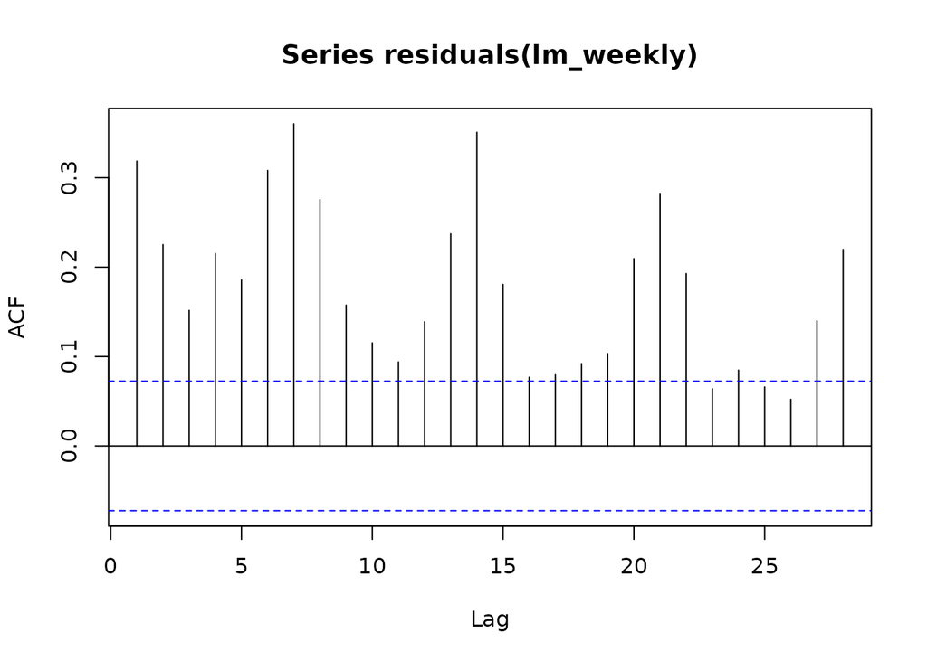

### ARIMAX model

Nyní zkusíme model ARIMAX, který kombinuje ARIMA model s externími regresory. Jako externí regresor použijeme `trzba`.

### Opravený dynamický lineární model (dynlm)

```
##
## Time series regression with "ts" data:
## Start = 2023(8), End = 2025(2)
##
## Call:
## dynlm(formula = ts_navs_zero ~ trend(ts_navs_zero) + season(ts_navs_zero) +
##     L(ts_navs_zero, 1) + L(ts_navs_zero, 7))
##
## Residuals:
##     Min      1Q  Median      3Q     Max
## -188.34  -16.77    0.00   16.77  188.34
##
## Coefficients:
##                           Estimate Std. Error t value Pr(>|t|)
## (Intercept)               -7.61166   43.64108  -0.174 0.861638
## trend(ts_navs_zero)       -1.40919    4.18602  -0.337 0.736585
## season(ts_navs_zero)2    112.21780   56.51574   1.986 0.047842 *
## season(ts_navs_zero)3    323.76308   69.68886   4.646 4.77e-06 ***
## season(ts_navs_zero)4    131.53008   69.97071   1.880 0.060951 .
## season(ts_navs_zero)5    143.83013   69.33800   2.074 0.038765 *
## season(ts_navs_zero)6    246.54858   69.96728   3.524 0.000481 ***
## season(ts_navs_zero)7    233.37277   68.98431   3.383 0.000797 ***
## season(ts_navs_zero)8    230.52670   56.70525   4.065 5.90e-05 ***
## season(ts_navs_zero)9     -5.89769   56.54962  -0.104 0.916996
## season(ts_navs_zero)10   245.24881   57.12609   4.293 2.27e-05 ***
## season(ts_navs_zero)11   112.94240   56.90418   1.985 0.047934 *
## season(ts_navs_zero)12   141.93168   56.67518   2.504 0.012715 *
## season(ts_navs_zero)13   225.92996   57.14588   3.954 9.28e-05 ***
## season(ts_navs_zero)14   180.44285   57.36703   3.145 0.001798 **
## season(ts_navs_zero)15   233.13081   57.67720   4.042 6.49e-05 ***
## season(ts_navs_zero)16   -11.34714   56.67155  -0.200 0.841418
## season(ts_navs_zero)17   188.43856   57.12430   3.299 0.001069 **
## season(ts_navs_zero)18   172.71833   56.65962   3.048 0.002473 **
## season(ts_navs_zero)19   150.56247   56.65823   2.657 0.008229 **
## season(ts_navs_zero)20   158.78531   57.23880   2.774 0.005827 **
## season(ts_navs_zero)21   153.42047   57.26936   2.679 0.007728 **
## season(ts_navs_zero)22   248.48636   57.79261   4.300 2.21e-05 ***
## season(ts_navs_zero)23     5.15124   56.61389   0.091 0.927552
## season(ts_navs_zero)24   183.78846   56.75571   3.238 0.001315 **
## season(ts_navs_zero)25   194.72813   56.82694   3.427 0.000682 ***
```

[output cut: 333 more lines]

```
## season(ts_navs_zero)359   93.37175   56.56924   1.651 0.099705 .
## season(ts_navs_zero)360   41.01304   56.48422   0.726 0.468255
## season(ts_navs_zero)361  234.70079   56.89303   4.125 4.61e-05 ***
## season(ts_navs_zero)362  228.91104   56.19587   4.073 5.71e-05 ***
## season(ts_navs_zero)363  165.67307   56.29831   2.943 0.003466 **
## season(ts_navs_zero)364  215.35216   56.27343   3.827 0.000153 ***
## season(ts_navs_zero)365   94.89566   56.28776   1.686 0.092688 .
## L(ts_navs_zero, 1)         0.55567    0.04373  12.706  < 2e-16 ***
## L(ts_navs_zero, 7)         0.04850    0.04510   1.075 0.282983
## ---
## Signif. codes:  0 '***' 0.001 '**' 0.01 '*' 0.05 '.' 0.1 ' ' 1
##
## Residual standard error: 56.11 on 357 degrees of freedom
## Multiple R-squared:  0.8586, Adjusted R-squared:  0.7131
## F-statistic: 5.904 on 367 and 357 DF,  p-value: < 2.2e-16
```

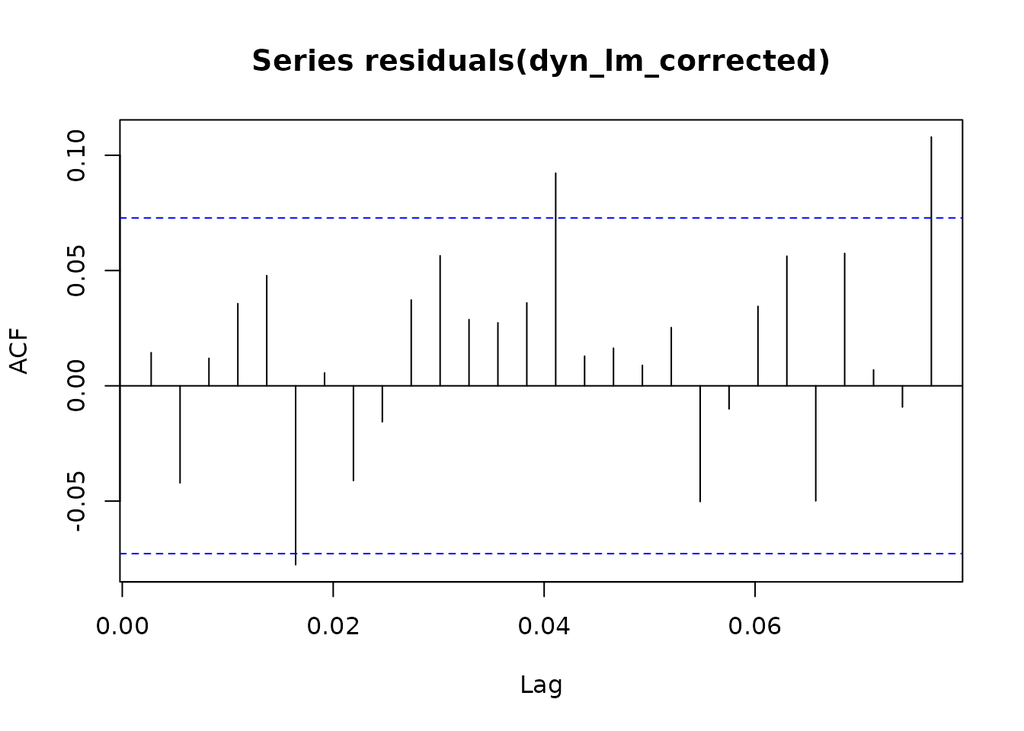